# Homework #4

Cole Weber

3/4/20

## Chick weights

The `ChickWeight` data set is part of the base package `datasets`. See `?ChickWeight` for details on the data. For all of the questions use `dplyr` functions with the pipe `%>%` whenever possible.

**Submission instructions**: Create a folder named `ds202_hw4`, and name the RMarkDown file including your solutions `hw4.Rmd` under this folder. For the submission, create a GitHub repository named `ds202_hw4` under your GitHub account, and push both `hw4.Rmd` and the knitted `hw4.html` before the deadline. I will assume you use the same GitHub username as for your HW3 submission. The latest version of your homework appearing on GitHub before the deadline is graded. *It is crucial to follow the exact folder structure and file names*. This homework is **due on March 4** before class.

```r
library(ggplot2)
library(dplyr)
library(datasets)
```

### Question 1:

Get a frequency breakdown of the number of chicks, their average weight and the standard deviation of the weights in each of the diets at the start of the study. Store the resulting data frame in a variable named `weight0` and print.

The frequency breakdown was determined by the summarize() with retreiving the mean(), sd(), and n() to all determine the mean, standard deviation, and count. The diets were at the start so the Time was 0 and didn’t elapse any time and were grouped by each of the diets.

```r
dat1 <- ChickWeight %>%
 filter(Time == 0) %>%
 group_by(Diet)

weight0 <- summarize(dat1, average_weight = mean(weight, na.rm = TRUE),
 sd_weight = sd(weight, na.rm = TRUE),number = n())

weight0
```

```
## # A tibble: 4 x 4
##   Diet  average_weight sd_weight number
##   <fct>          <dbl>     <dbl>  <int>
## 1 1               41.4     0.995     20
## 2 2               40.7     1.49      10
## 3 3               40.8     1.03      10
## 4 4               41       1.05      10
```

Below the ggplot shows the average weights by diet with an interveal of standard deviation as the + or - around the averages. Interpretting the graph seems like the average weight starts high average weight and small standard deviation with the first diet. Then with the second diet, the average weight goes down but the standard deviation gets higher. Finally, the third and fourth diet, the average weight grows but the standard deviation declines from the second diet.

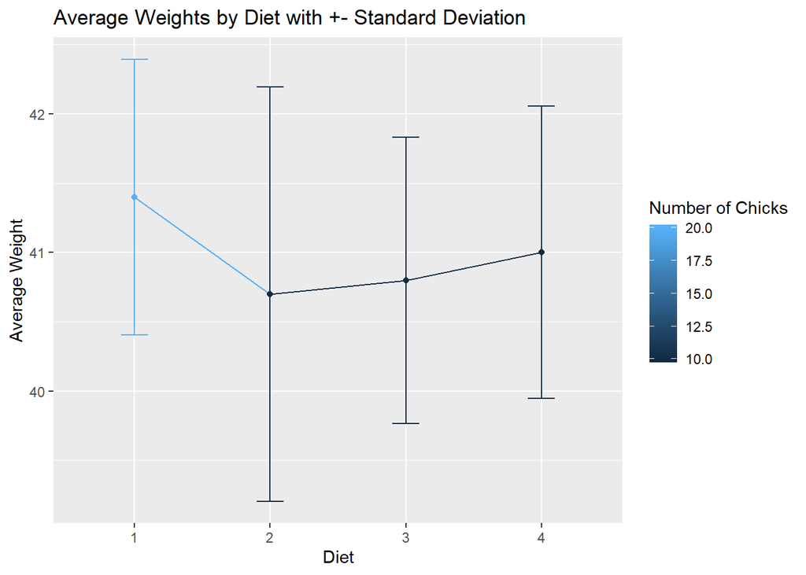

```r
ggplot(weight0, aes(x=Diet, y=average_weight, colour=number, group=1)) +
    geom_errorbar(aes(ymin=average_weight-sd_weight, ymax=average_weight+sd_weight), width=.2) +
    geom_line() +
    geom_point() + labs(x = "Diet", y = "Average Weight", title = "Average Weights by Diet with +- Standard Deviation", colour = "Number of Chicks")
```

### Question 2:

Each chick should have twelve weight measurements. Use the `dplyr` package to identify how many measurements are there for each chick. Extract a subset of the data for all chicks with complete information, name the data set `complete`, and print the first 3 rows. (Hint: you might want to use mutate to introduce a helper variable consisting of the number of observations)

Since each does doesn’t have complete information meaning it doesn’t have 12 rows, those chicks had to be dropped. This was done by creating a numComplete variable that kept track of how many counts there are in the Chick column.

```r
final <- ChickWeight %>% group_by(Chick) %>% mutate(numComplete = n())
complete <- subset(final, final$numComplete==12)
head(complete,3)
```

```
## # A tibble: 3 x 5
## # Groups:   Chick [1]
##   weight  Time Chick Diet  numComplete
##    <dbl> <dbl> <ord> <fct>       <int>
## 1     42     0 1     1              12
## 2     51     2 1     1              12
## 3     59     4 1     1              12
```

### Question 3:

In the complete data set introduce a new variable that measures the current weight difference compared to day 0. Name this variable `weightgain` and print the first 3 rows of the new data frame.

The function mutate() was used to create a new variable that used the diff() to create the difference between the day and the future days. This was also grouped by the chick column. It’s clear that the difference varies amongst the days because it has both positive and negative numbers meaning that depending on the day, it could be different.

```r
complete <- complete %>% group_by(Chick) %>% mutate(weightgain = c(0,diff(weight)))
head(complete,3)
```

```
## # A tibble: 3 x 6
## # Groups:   Chick [1]
##   weight  Time Chick Diet  numComplete weightgain
##    <dbl> <dbl> <ord> <fct>       <int>      <dbl>
## 1     42     0 1     1              12          0
## 2     51     2 1     1              12          9
## 3     59     4 1     1              12          8
```

### Question 4:

Use `{ggplot2}` to create side-by-side boxplots of `weightgain` by `Diet` for day 21. Change the order of the categories in the Diet variable such that the boxplots are ordered by median `weightgain`, and the lower limit of the y axis should be 0. Describe the relationship in 2-3 sentences.

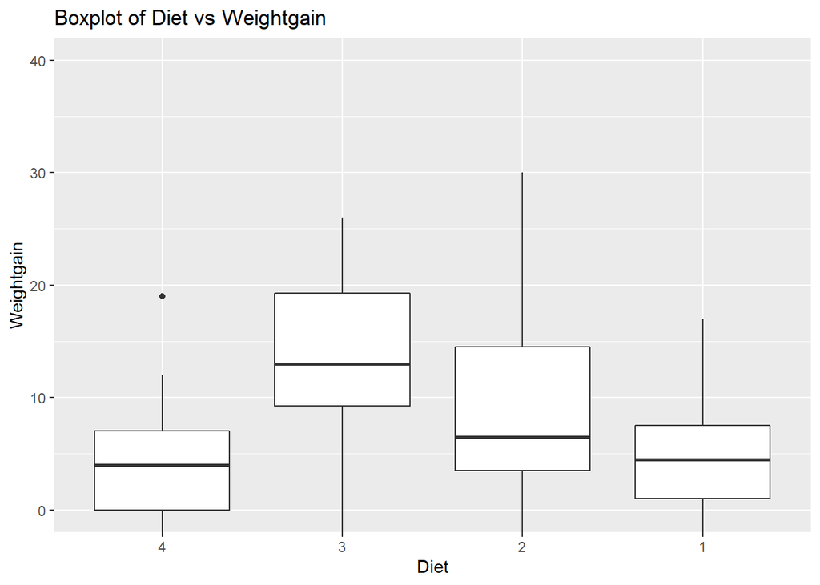

```r
medians = complete %>% group_by(Diet) %>% summarize(median = median(weightgain)) %>% arrange(median)
boxP <- complete %>% filter(Time==21) %>% mutate(Diet = factor(Diet, levels = c(rev(medians$Diet)))) %>%  ggplot(boxP, mapping =aes(x=Diet, y=weightgain)) +
  geom_boxplot() + coord_cartesian(ylim = c(0,40)) + labs(x = "Diet", y = "Weightgain", title = "Boxplot of Diet vs Weightgain")
boxP
```

### Question 5:

Answer each of the following questions using numerical and graphical summary. Also explain what you found: (a) Which chick gained the most weight and which gained the least weight? (b) What diets were they on?

Numeric Results:

```r
minChick <- complete %>% filter(Time==21) %>% filter(weightgain ==min(weightgain))
minChick[which.min(minChick$weightgain),]
```

```
## # A tibble: 1 x 6
## # Groups:   Chick [1]
##   weight  Time Chick Diet  numComplete weightgain
##    <dbl> <dbl> <ord> <fct>       <int>      <dbl>
## 1    147    21 33    3              12         -9
```

```r
maxChick <- complete %>% filter(Time==21) %>% filter(weightgain ==max(weightgain))
maxChick[which.max(maxChick$weightgain),]
```

```
## # A tibble: 1 x 6
## # Groups:   Chick [1]
##   weight  Time Chick Diet  numComplete weightgain
##    <dbl> <dbl> <ord> <fct>       <int>      <dbl>
## 1    309    21 29    2              12         30
```

Graphical Results

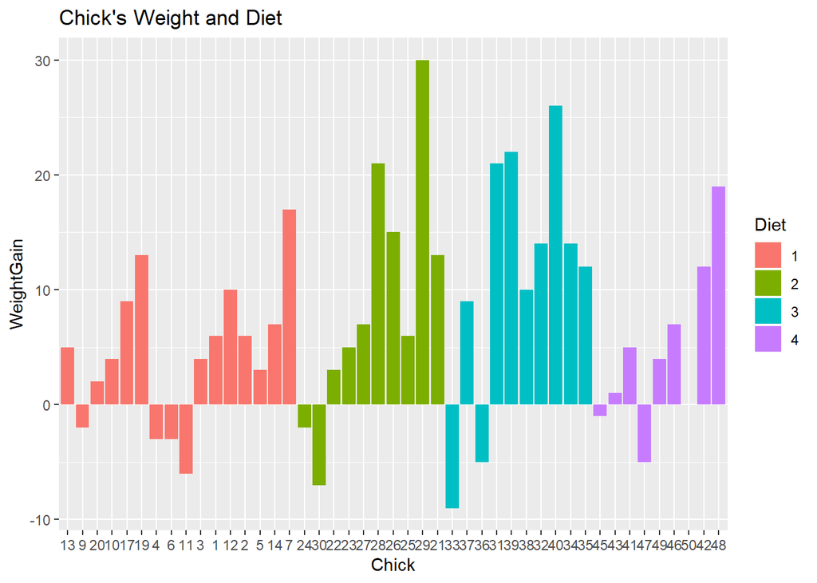

```r
q5 <-  ggplot(maxChick, aes(Chick,y= weightgain)) + geom_bar(aes(fill = Diet), stat = "identity") + labs(x = "Chick", y = "WeightGain", title = "Chick's Weight and Diet",fill = "Diet")
q5
```

### Question 6:

For the chicks with the least and the most weight at time 0, plot their growth trajectories over time.

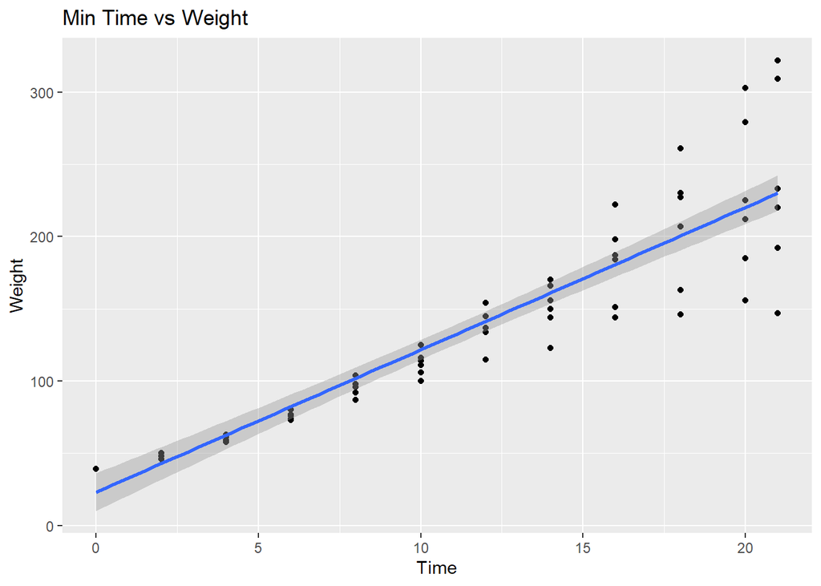

```r
minChickT <- complete %>% group_by(Chick) %>% filter(Time==0)
minChickT <- complete %>% group_by(Time) %>% filter(minChickT$weight == min(minChickT$weight))

maxChickT <- complete %>% group_by(Chick) %>% filter(Time==0)
maxChickT <- complete %>% group_by(Time) %>% filter(maxChickT$weight == max(maxChickT$weight))

    ggplot(minChickT, aes(Time, weight)) +
     geom_point() +
     geom_smooth(method="lm") + labs(x = "Time", y = "Weight", title = "Min Time vs Weight")
```

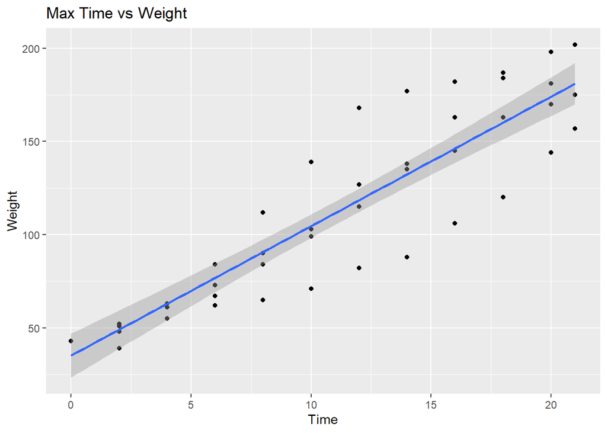

```r
  ggplot(maxChickT, aes(Time, weight)) +
     geom_point() +
     geom_smooth(method="lm") + labs(x = "Time", y = "Weight", title = "Max Time vs Weight")
```

### Question 7:

Add to the previous plot the average growth trajectory for all chicks (calculated as the mean weight for each chick at each time). How do the trajectories compare?

The trajectries compare to each other in similar ways but are not identical. Both of these trajectories are positive which means the slope is moving from bottom left to top right. Another similarity is that the mean weight value was both over 100 for each trajectory. The max value had a value of 110.98 while the min value had a value of 130.75 which both were implemented by simply adding the mean weight of the facet_wrap().

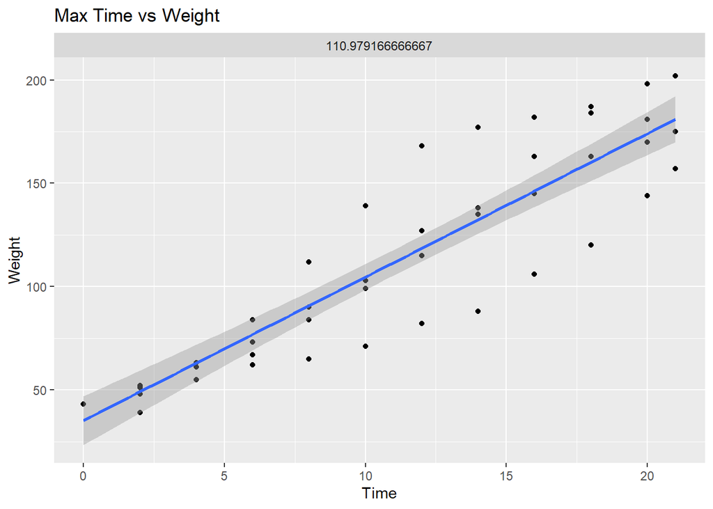

```r
 ggplot(maxChickT, aes(Time, weight)) +
     geom_point() +
     geom_smooth(method="lm") + facet_wrap(~mean(weight))  + labs(x = "Time", y = "Weight", title = "Max Time vs Weight")
```

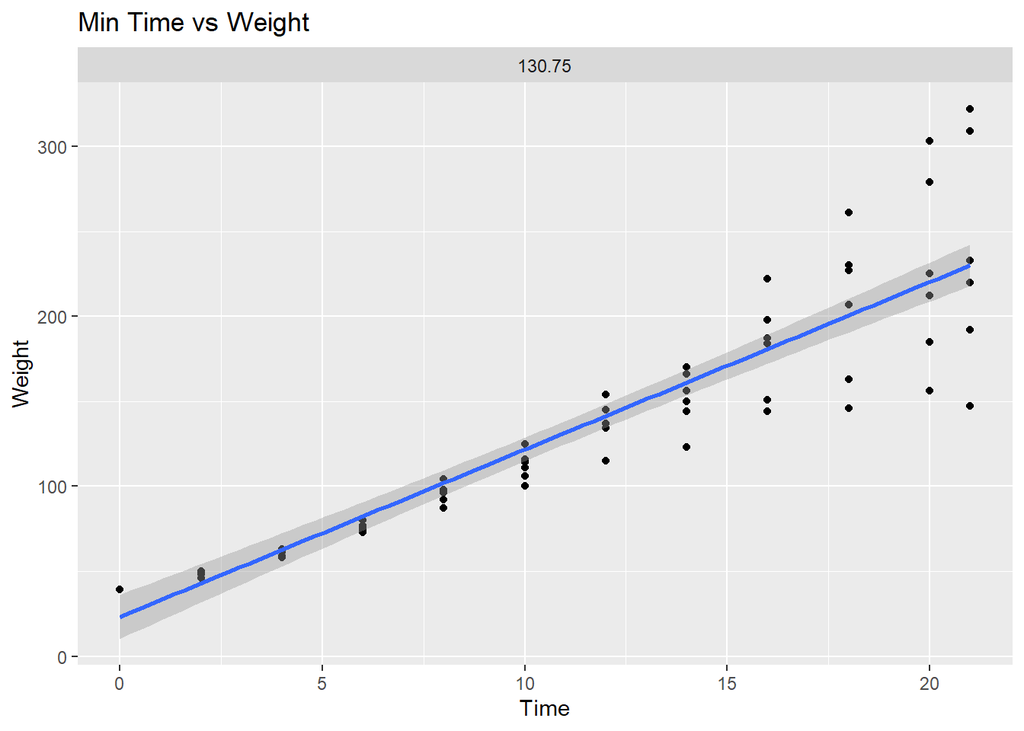

```r
ggplot(minChickT, aes(Time, weight)) +
     geom_point() +
     geom_smooth(method="lm") + facet_wrap(~mean(weight))  + labs(x = "Time", y = "Weight", title = "Min Time vs Weight")
```

### Question 8:

What else do you find interesting in the dataset? Show your exploratory analysis.

Timing is one thing that I found interesting about this dataset. I wanted to look more in depth of how the timing can affect all different types of diets and weightgained. I filtered out three different times which basically split up the plot into three simple parts of time (1/3s). Then a simple bargraph displays the results of each column that was looked at Diet, Weightgain, and Time.

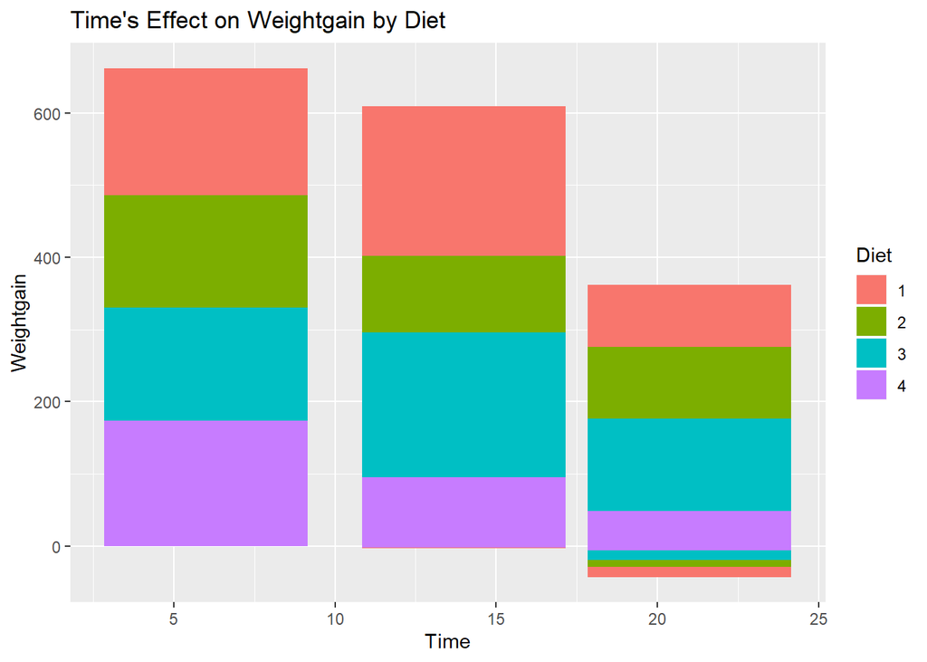

```r
g <- complete %>% filter(Time==6 | Time==14 | Time ==21)
ggplot(g, aes(x=Time,y = weightgain)) +geom_bar(aes(fill = Diet),stat = "identity") + labs(x = "Time", y = "Weightgain", title = "Time's Effect on Weightgain by Diet", fill = "Diet")
```

Note: your submission is supposed to be fully reproducible, i.e. the TA and I will ‘knit’ your submission in RStudio.